# RTutor.ai report

RTutor v.2.00, Powered by ChatGPT

Tue Dec 31 19:12:49 2024

Developed by [Steven Ge](https://twitter.com/StevenXGe) using API access via the [openai](https://cran.rstudio.com/web/packages/openai/index.html) package to [OpenAI’s](https://cran.rstudio.com/web/packages/openai/index.html) “GPT-4o” model.

RTutor Website: https://RTutor.ai Source code: [GitHub.](https://github.com/gexijin/RTutor)

### 1. Create a boxplot of highway vs. class. Color by class.

GPT-4o (Temperature = 0.2)

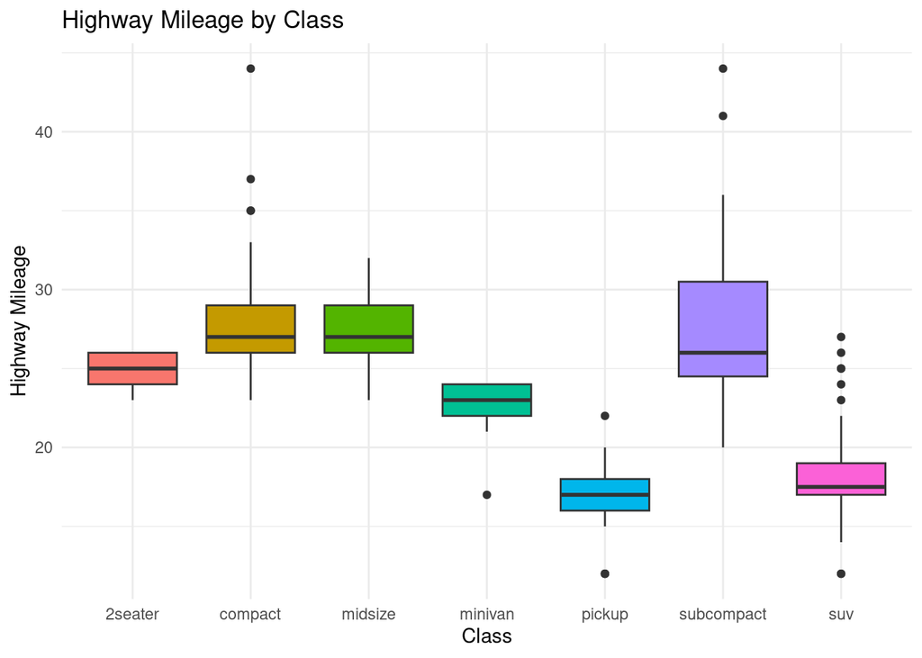

```r
library(ggplot2)

# Create the boxplot
ggplot(df, aes(x = class, y = hwy, fill = class)) +
  geom_boxplot() +
  labs(title = "Highway Mileage by Class", x = "Class", y = "Highway Mileage") +
  theme_minimal() +
  theme(legend.position = "none")
```

### 2. Create a boxplot of city vs. class.

GPT-4o (Temperature = 0.2)

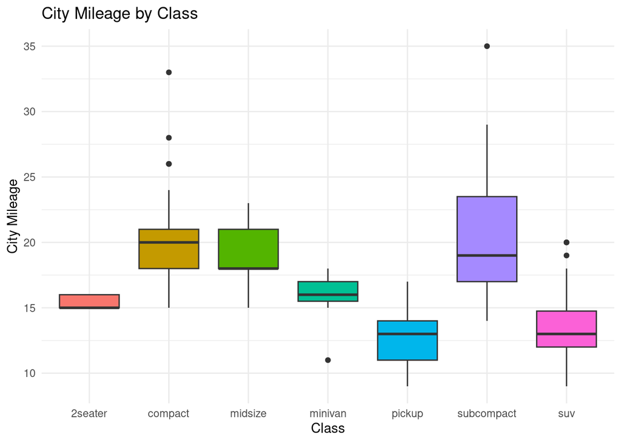

```r
library(ggplot2)

# Create the boxplot
ggplot(df, aes(x = class, y = cty, fill = class)) +
  geom_boxplot() +
  labs(title = "City Mileage by Class", x = "Class", y = "City Mileage") +
  theme_minimal() +
  theme(legend.position = "none")
```

### 3. Plot hwy vs. cty, colored by class. Change shape by drv.

GPT-4o (Temperature = 0.2)

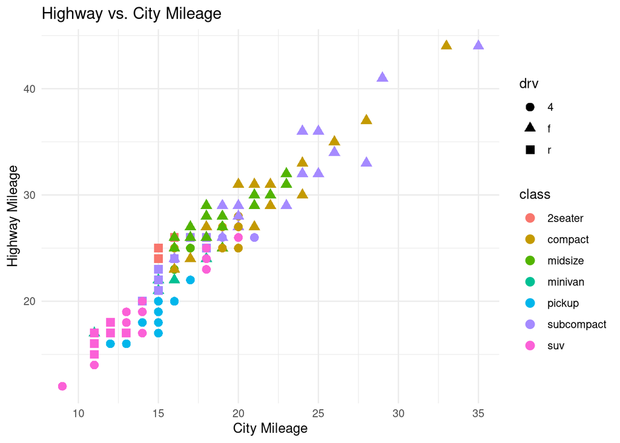

```r
library(ggplot2)

# Create the scatter plot
ggplot(df, aes(x = cty, y = hwy, color = class, shape = drv)) +
  geom_point(size = 3) +
  labs(title = "Highway vs. City Mileage", x = "City Mileage", y = "Highway Mileage") +
  theme_minimal()
```

### 4. Conduct ANOVA of hwy by class.

GPT-4o (Temperature = 0.2)

```r
# Conduct ANOVA of hwy by class
anova_result <- aov(hwy ~ class, data = df)

# Display the summary of the ANOVA
summary(anova_result)
```

```
##              Df Sum Sq Mean Sq F value Pr(>F)
## class         6   5683   947.2   83.39 <2e-16 ***
## Residuals   227   2578    11.4
## ---
## Signif. codes:  0 '***' 0.001 '**' 0.01 '*' 0.05 '.' 0.1 ' ' 1
```

### 5. Create a boxplot of hwy vs. class. Color by class.

GPT-4o (Temperature = 0.2)

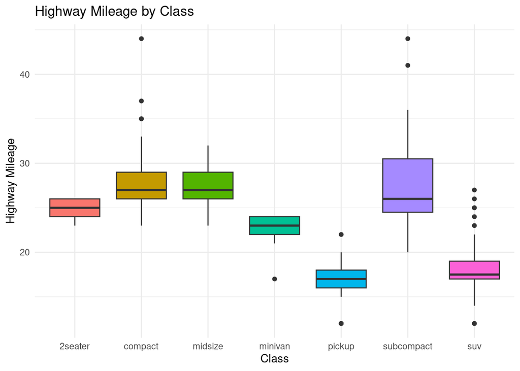

```r
library(ggplot2)

# Create the boxplot
ggplot(df, aes(x = class, y = hwy, fill = class)) +
  geom_boxplot() +
  labs(title = "Highway Mileage by Class", x = "Class", y = "Highway Mileage") +
  theme_minimal() +
  theme(legend.position = "none")
```

### 6. Conduct ANOVA of log-transformed hwy by class and drv.

GPT-4o (Temperature = 0.2)

```r
# Conduct ANOVA of log-transformed hwy by class and drv
anova_result <- aov(log(hwy) ~ class * drv, data = df)

# Display the summary of the ANOVA
summary(anova_result)
```

```
##              Df Sum Sq Mean Sq F value  Pr(>F)
## class         6 11.477  1.9128  115.42 < 2e-16 ***
## drv           2  0.606  0.3028   18.27 4.5e-08 ***
## class:drv     3  0.037  0.0123    0.74   0.529
## Residuals   222  3.679  0.0166
## ---
## Signif. codes:  0 '***' 0.001 '**' 0.01 '*' 0.05 '.' 0.1 ' ' 1
```

### 7. Create a correlation map of all the columns that contain numbers.

GPT-4o (Temperature = 0.2)

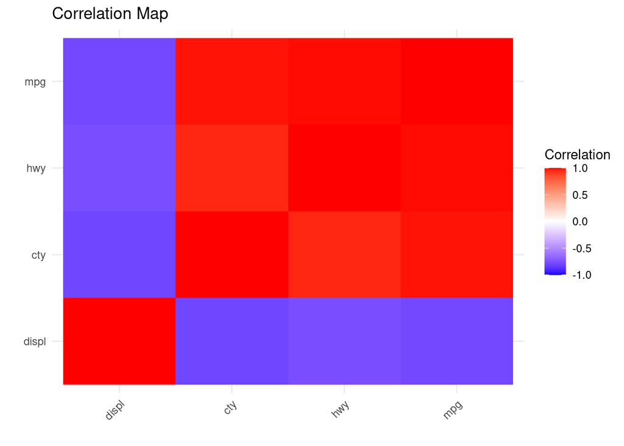

```r
library(ggplot2)
library(reshape2)

# Select numeric columns
numeric_columns <- df[, sapply(df, is.numeric)]

# Compute correlation matrix
cor_matrix <- cor(numeric_columns, use = "complete.obs")

# Melt the correlation matrix for visualization
cor_melt <- melt(cor_matrix)

# Create the correlation map
ggplot(cor_melt, aes(Var1, Var2, fill = value)) +
  geom_tile() +
  scale_fill_gradient2(low = "blue", high = "red", mid = "white", midpoint = 0, limit = c(-1, 1)) +
  labs(title = "Correlation Map", x = "", y = "", fill = "Correlation") +
  theme_minimal() +
  theme(axis.text.x = element_text(angle = 45, hjust = 1))
```

### 8. Use corrplot to create a correlation plot of all the columns that contain numbers.

GPT-4o (Temperature = 0.2)

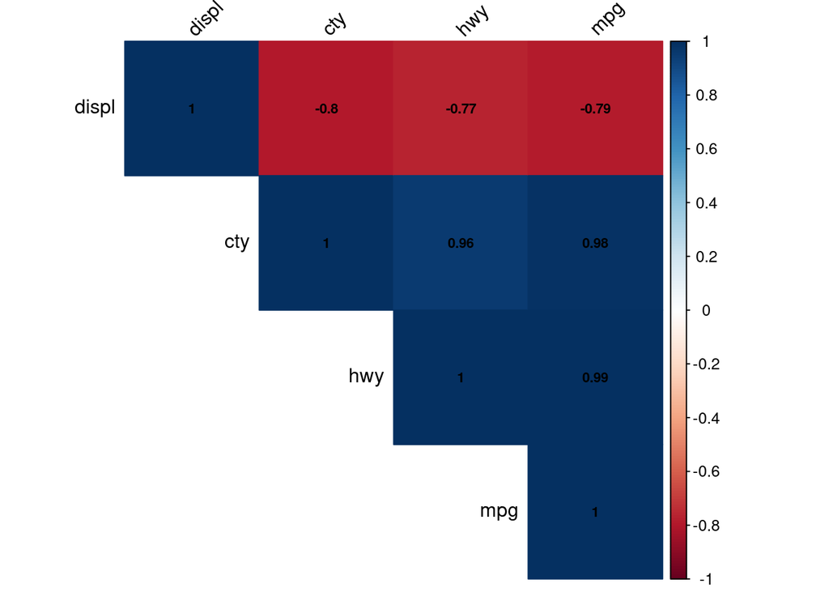

```r
library(corrplot)

# Select numeric columns
numeric_columns <- df[, sapply(df, is.numeric)]

# Compute correlation matrix
cor_matrix <- cor(numeric_columns, use = "complete.obs")

# Create the correlation plot
corrplot(cor_matrix, method = "color", type = "upper", tl.col = "black", tl.srt = 45, addCoef.col = "black", number.cex = 0.7)
```

### 9. Calculate average cty by year and class.

GPT-4o (Temperature = 0.2)

```r
# Calculate average cty by year and class
average_cty <- aggregate(cty ~ year + class, data = df, FUN = mean)

# Display the result
average_cty
```

```
##    year      class      cty
## 1  1999    2seater 15.50000
## 2  2008    2seater 15.33333
## 3  1999    compact 19.76000
## 4  2008    compact 20.54545
## 5  1999    midsize 18.15000
## 6  2008    midsize 19.33333
## 7  1999    minivan 16.16667
## 8  2008    minivan 15.40000
## 9  1999     pickup 13.00000
## 10 2008     pickup 13.00000
## 11 1999 subcompact 21.57895
## 12 2008 subcompact 18.93750
## 13 1999        suv 13.37931
## 14 2008        suv 13.60606
```

### 10. Create a barplot of average mpg by class, colored by year. The years should be side by side.

GPT-4o (Temperature = 0.2)

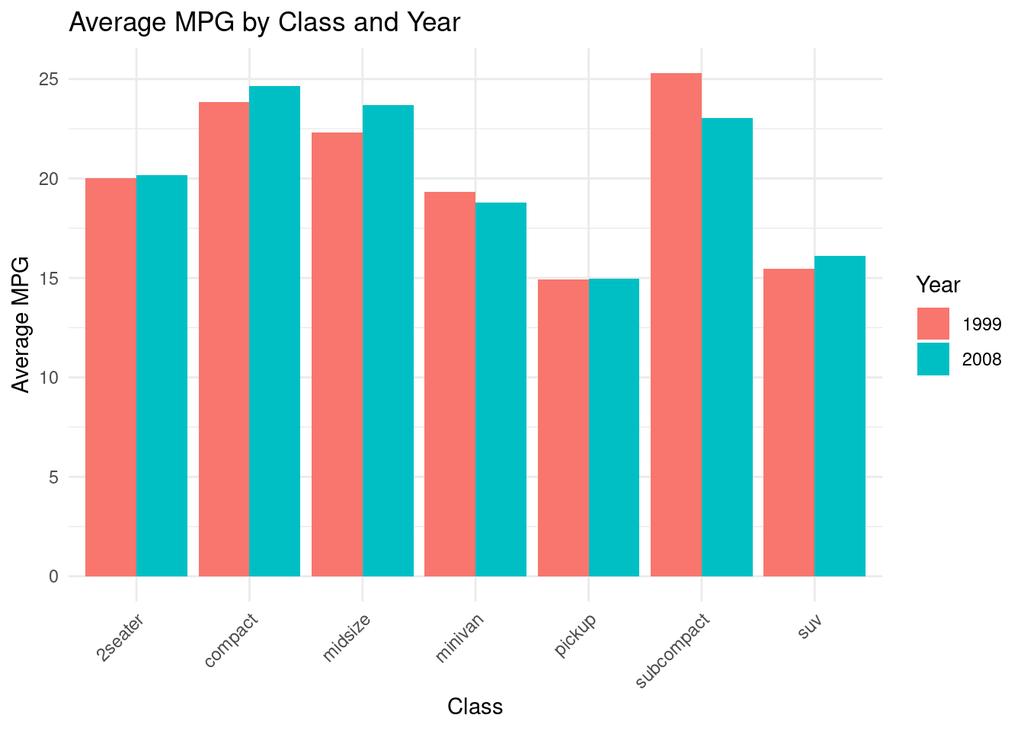

```r
library(ggplot2)

# Calculate average mpg (cty and hwy combined) by class and year
df$mpg <- (df$cty + df$hwy) / 2
average_mpg <- aggregate(mpg ~ class + year, data = df, FUN = mean)

# Create the barplot
ggplot(average_mpg, aes(x = class, y = mpg, fill = factor(year))) +
  geom_bar(stat = "identity", position = "dodge") +
  labs(title = "Average MPG by Class and Year", x = "Class", y = "Average MPG", fill = "Year") +
  theme_minimal() +
  theme(axis.text.x = element_text(angle = 45, hjust = 1))
```

### 11. Calculate the correlation of cty vs hwy. Repeat that after log transformation. Collect these results and show them.

GPT-4o (Temperature = 0.2)

```r
# Calculate correlation of cty vs hwy
cor_cty_hwy <- cor(df$cty, df$hwy, use = "complete.obs")

# Calculate correlation of log-transformed cty vs hwy
cor_log_cty_hwy <- cor(log(df$cty), log(df$hwy), use = "complete.obs")

# Collect and show results
results <- data.frame(
  Transformation = c("Original", "Log-Transformed"),
  Correlation = c(cor_cty_hwy, cor_log_cty_hwy)
)

results
```

```
##    Transformation Correlation
## 1        Original   0.9559159
## 2 Log-Transformed   0.9556827
```

### 12. Hwy and cty represent miles per gallon (MPG) on the highway and in the city, respectively. Only keep cars more efficient than 15 MPG, but less than 40, on the highway. Add 0.5 to city MPG for correction. Perform log transformation on city MPG. Raise highway MPG to the second power. Calculate correlation coefficient of the two transformed variables.

GPT-4o (Temperature = 0.2)

```r
# Filter cars with highway MPG between 15 and 40
df_filtered <- df[df$hwy > 15 & df$hwy < 40, ]

# Add 0.5 to city MPG for correction
df_filtered$cty <- df_filtered$cty + 0.5

# Perform log transformation on city MPG
df_filtered$log_cty <- log(df_filtered$cty)

# Raise highway MPG to the second power
df_filtered$hwy_squared <- df_filtered$hwy^2

# Calculate correlation coefficient of the two transformed variables
correlation <- cor(df_filtered$log_cty, df_filtered$hwy_squared, use = "complete.obs")

# Show the correlation coefficient
correlation
```

```
## [1] 0.9334202
```